# Principal Component Analysis with Cancer Data

# Q7 Identify eigen values and eigen vector

```python
# Step 2- Get eigen values and eigen vector
```

```python
eigenvalues, eigenvectors = np.linalg.eig(train_cov_matrix)
print('Eigen Vectors \n%s', eigenvectors)
print('\n Eigen Values \n%s', eigenvalues)
```

```
Eigen Vectors
%s [[-3.11037234e-01 -3.22826731e-02  2.76763140e-02  8.90780897e-01
  -8.06390210e-02 -1.83772661e-01 -1.41845538e-01 -2.08445141e-01
   6.41288372e-02]
 [-3.70498878e-01  7.01763238e-02  7.29794637e-01  2.98182651e-02
   3.24376132e-01  2.56745003e-01  2.48641037e-01  2.80161507e-01
   1.13427586e-01]
 [-3.67276822e-01  8.73429464e-02 -6.69123013e-01  1.17611428e-01
   2.56079907e-01  3.69972681e-01  3.09482794e-01  3.12545116e-01
   3.72745972e-04]
 [-3.39906357e-01  8.43695106e-02 -5.21715151e-02 -2.60433788e-01
  -4.83780165e-02 -1.48214691e-01  4.46355739e-01 -6.64044890e-01
   3.77227704e-01]
 [-3.48697468e-01  4.95573642e-02 -4.40270682e-02 -1.77375963e-01
   3.91206987e-01 -6.57684713e-01 -5.05072296e-02  5.74891800e-02
  -5.01104235e-01]
 [-3.33909118e-01  7.41510283e-02  9.95817254e-02 -7.37480138e-02
  -6.70717777e-01  2.28907347e-01  1.44769721e-01 -3.62351906e-02
  -5.85763490e-01]
 [-3.33975570e-01  2.57200823e-01 -5.43814977e-02 -1.77661049e-01
  -4.08257477e-01 -3.03315000e-01 -2.84067230e-01  4.60344238e-01
   4.86314810e-01]
 [-3.38948727e-01  5.94295019e-02 -2.80807011e-02 -2.04835684e-01
   2.09316314e-01  4.04691225e-01 -7.19969809e-01 -3.35564345e-01
  -1.69543493e-02]
 [-2.36741802e-01 -9.49551300e-01 -2.41983634e-02 -1.16361298e-01
  -8.34709075e-02 -2.71937692e-02 -2.20105352e-02  1.01399440e-01
   9.85237604e-02]]

 Eigen Values
%s [6.11148664 0.7138128  0.08937636 0.47519981 0.43174897 0.23512652
 0.3549833  0.31862892 0.28807932]
```

# Q8 Find variance and cumulative variance by each eigen vector

```python
#Sort eigenvalues in descending order

#set of (eigenvalue, eigenvector) pairs
train_eig_pairs = [(eigenvalues[index], eigenvectors[:,index]) for index in range(len(eigenvalues))]

# Sorting the (eigenvalue, eigenvector) pairs from highest to lowest with respect to eigenvalue
train_eig_pairs.sort()

train_eig_pairs.reverse()
print(train_eig_pairs)

# Extract the descending ordered eigenvalues and eigenvectors
train_eigvalues_sorted = [train_eig_pairs[index][0] for index in range(len(eigenvalues))]
train_eigvectors_sorted = [train_eig_pairs[index][1] for index in range(len(eigenvalues))]

# Let's confirm our sorting worked, print out eigenvalues
print('Eigenvalues in descending order: \n%s' %train_eigvalues_sorted)
```

```
[(6.111486635085383, array([-0.31103723, -0.37049888, -0.36727682, -0.33990636, -0.34869747,
       -0.33390912, -0.33397557, -0.33894873, -0.2367418 ])), (0.7138127954493263, array([-0.03228267,  0.07017632,  0.08734295,  0.08436951,  0.04955736,
        0.07415103,  0.25720082,  0.0594295 , -0.9495513 ])), (0.4751998088643037, array([ 0.8907809 ,  0.02981827,  0.11761143, -0.26043379, -0.17737596,
       -0.07374801, -0.17766105, -0.20483568, -0.1163613 ])), (0.43174896601925844, array([-0.08063902,  0.32437613,  0.25607991, -0.04837802,  0.39120699,
       -0.67071778, -0.40825748,  0.20931631, -0.08347091])), (0.354983302139976, array([-0.14184554,  0.24864104,  0.30948279,  0.44635574, -0.05050723,
        0.14476972, -0.28406723, -0.71996981, -0.02201054])), (0.318628923357038, array([-0.20844514,  0.28016151,  0.31254512, -0.66404489,  0.05748918,
       -0.03623519,  0.46034424, -0.33556435,  0.10139944])), (0.2880793165846668, array([ 6.41288372e-02,  1.13427586e-01,  3.72745972e-04,  3.77227704e-01,
       -5.01104235e-01, -5.85763490e-01,  4.86314810e-01, -1.69543493e-02,
        9.85237604e-02])), (0.23512651950730648, array([-0.18377266,  0.256745  ,  0.36997268, -0.14821469, -0.65768471,
        0.22890735, -0.303315  ,  0.40469123, -0.02719377])), (0.08937635594356112, array([ 0.02767631,  0.72979464, -0.66912301, -0.05217152, -0.04402707,
        0.09958173, -0.0543815 , -0.0280807 , -0.02419836]))]
Eigenvalues in descending order:
[6.111486635085383, 0.7138127954493263, 0.4751998088643037, 0.43174896601925844, 0.354983302139976, 0.318628923357038, 0.2880793165846668, 0.23512651950730648, 0.08937635594356112]
```

```python
tot = sum(eigenvalues)
var_explained = [(i / tot) for i in sorted(train_eigvalues_sorted, reverse=True)]
cum_var_exp = np.cumsum(var_explained)
```

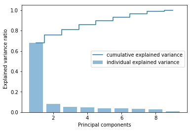

```python
plt.bar(range(1,10), var_explained, alpha=0.5, align='center', label='individual explained variance')
plt.step(range(1,10),cum_var_exp, where= 'mid', label='cumulative explained variance')
plt.ylabel('Explained variance ratio')
plt.xlabel('Principal components')
plt.legend(loc = 'best')
plt.show()
```

# Q9 Use PCA command from sklearn and find Principal Components. Transform data to components formed

```python
X
```

| ID | ClumpThickness | Cell Size | Cell Shape | Marginal Adhesion | Single Epithelial Cell Size | Bare Nuclei | Normal Nucleoli | Bland Chromatin | Mitoses |
| --- | --- | --- | --- | --- | --- | --- | --- | --- | --- |
| 1000025 | 5 | 1 | 1 | 1 | 2 | 1.0 | 3 | 1 | 1 |
| 1002945 | 5 | 4 | 4 | 5 | 5 | 10.0 | 3 | 2 | 1 |
| 1015425 | 3 | 1 | 1 | 1 | 2 | 2.0 | 3 | 1 | 1 |
| 1016277 | 6 | 8 | 8 | 1 | 3 | 4.0 | 3 | 5 | 1 |
| 1017023 | 4 | 1 | 1 | 3 | 2 | 1.0 | 3 | 1 | 1 |
| 1017122 | 8 | 10 | 10 | 5 | 5 | 10.0 | 5 | 5 | 1 |
| 1018099 | 1 | 1 | 1 | 1 | 2 | 10.0 | 3 | 1 | 1 |
| 1018561 | 2 | 1 | 2 | 1 | 2 | 1.0 | 3 | 1 | 1 |
| 1033078 | 2 | 1 | 1 | 1 | 2 | 1.0 | 1 | 1 | 5 |
| 1033078 | 4 | 2 | 1 | 1 | 2 | 1.0 | 2 | 1 | 1 |
| 1035283 | 1 | 1 | 1 | 1 | 1 | 1.0 | 3 | 1 | 1 |
| 1036172 | 2 | 1 | 1 | 1 | 2 | 1.0 | 2 | 1 | 1 |
| 1041801 | 5 | 3 | 3 | 3 | 2 | 3.0 | 4 | 4 | 1 |
| 1043999 | 1 | 1 | 1 | 1 | 2 | 3.0 | 3 | 1 | 1 |
| 1044572 | 8 | 7 | 5 | 5 | 5 | 9.0 | 5 | 5 | 4 |
| 1047630 | 7 | 4 | 6 | 4 | 5 | 1.0 | 4 | 3 | 1 |
| 1048672 | 4 | 1 | 1 | 1 | 2 | 1.0 | 2 | 1 | 1 |
| 1049815 | 4 | 1 | 1 | 1 | 2 | 1.0 | 3 | 1 | 1 |
| 1050670 | 10 | 7 | 7 | 5 | 4 | 10.0 | 4 | 1 | 2 |
| 1050718 | 6 | 1 | 1 | 1 | 2 | 1.0 | 3 | 1 | 1 |
| 1054590 | 7 | 3 | 2 | 5 | 5 | 10.0 | 5 | 4 | 4 |
| 1054593 | 10 | 5 | 5 | 3 | 5 | 7.0 | 5 | 5 | 1 |
| 1056784 | 3 | 1 | 1 | 1 | 2 | 1.0 | 2 | 1 | 1 |
| 1057013 | 8 | 4 | 5 | 1 | 2 | 1.0 | 5 | 3 | 1 |
| 1059552 | 1 | 1 | 1 | 1 | 2 | 1.0 | 3 | 1 | 1 |
| 1065726 | 5 | 2 | 3 | 4 | 2 | 7.0 | 3 | 5 | 1 |
| 1066373 | 3 | 2 | 1 | 1 | 1 | 1.0 | 2 | 1 | 1 |
| 1066979 | 5 | 1 | 1 | 1 | 2 | 1.0 | 2 | 1 | 1 |
| 1067444 | 2 | 1 | 1 | 1 | 2 | 1.0 | 2 | 1 | 1 |
| 1070935 | 1 | 1 | 3 | 1 | 2 | 1.0 | 1 | 1 | 1 |
| ... | ... | ... | ... | ... | ... | ... | ... | ... | ... |
| 1350423 | 5 | 10 | 10 | 5 | 5 | 5.0 | 5 | 5 | 1 |
| 1352848 | 3 | 10 | 7 | 5 | 5 | 8.0 | 5 | 4 | 1 |
| 1353092 | 3 | 2 | 1 | 2 | 2 | 1.0 | 3 | 1 | 1 |
| 1354840 | 2 | 1 | 1 | 1 | 2 | 1.0 | 3 | 1 | 1 |
| 1354840 | 5 | 3 | 2 | 1 | 3 | 1.0 | 1 | 1 | 1 |
| 1355260 | 1 | 1 | 1 | 1 | 2 | 1.0 | 2 | 1 | 1 |
| 1365075 | 4 | 1 | 4 | 1 | 2 | 1.0 | 1 | 1 | 1 |
| 1365328 | 1 | 1 | 2 | 1 | 2 | 1.0 | 2 | 1 | 1 |
| 1368267 | 5 | 1 | 1 | 1 | 2 | 1.0 | 1 | 1 | 1 |
| 1368273 | 1 | 1 | 1 | 1 | 2 | 1.0 | 1 | 1 | 1 |
| 1368882 | 2 | 1 | 1 | 1 | 2 | 1.0 | 1 | 1 | 1 |
| 1369821 | 10 | 10 | 10 | 5 | 5 | 10.0 | 5 | 5 | 5 |
| 1371026 | 5 | 10 | 10 | 5 | 4 | 10.0 | 5 | 5 | 3 |
| 1371920 | 5 | 1 | 1 | 1 | 2 | 1.0 | 3 | 2 | 1 |
| 466906 | 1 | 1 | 1 | 1 | 2 | 1.0 | 1 | 1 | 1 |
| 466906 | 1 | 1 | 1 | 1 | 2 | 1.0 | 1 | 1 | 1 |
| 534555 | 1 | 1 | 1 | 1 | 2 | 1.0 | 1 | 1 | 1 |
| 536708 | 1 | 1 | 1 | 1 | 2 | 1.0 | 1 | 1 | 1 |
| 566346 | 3 | 1 | 1 | 1 | 2 | 1.0 | 2 | 3 | 1 |
| 603148 | 4 | 1 | 1 | 1 | 2 | 1.0 | 1 | 1 | 1 |
| 654546 | 1 | 1 | 1 | 1 | 2 | 1.0 | 1 | 1 | 5 |
| 654546 | 1 | 1 | 1 | 3 | 2 | 1.0 | 1 | 1 | 1 |
| 695091 | 5 | 10 | 10 | 5 | 4 | 5.0 | 4 | 4 | 1 |
| 714039 | 3 | 1 | 1 | 1 | 2 | 1.0 | 1 | 1 | 1 |
| 763235 | 3 | 1 | 1 | 1 | 2 | 1.0 | 2 | 1 | 2 |
| 776715 | 3 | 1 | 1 | 1 | 3 | 2.0 | 1 | 1 | 1 |
| 841769 | 2 | 1 | 1 | 1 | 2 | 1.0 | 1 | 1 | 1 |
| 888820 | 5 | 10 | 10 | 3 | 5 | 3.0 | 5 | 5 | 2 |
| 897471 | 4 | 8 | 6 | 4 | 3 | 4.0 | 5 | 5 | 1 |
| 897471 | 4 | 8 | 8 | 5 | 4 | 5.0 | 5 | 4 | 1 |

699 rows × 9 columns

```python
pc=dec.PCA()
X_bis = pc.fit_transform(X)
```

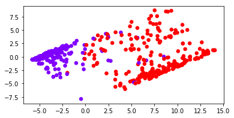

```python
plt.figure(figsize=(6,3));
plt.scatter(X_bis[:,0], X_bis[:,1], c=y,
            s=30, cmap=plt.cm.rainbow);
```

```python
pc.components_
```

```
array([[ 0.35966257,  0.46445478,  0.45409633,  0.21633575,  0.1773255 ,
         0.52554866,  0.19341714,  0.22013345,  0.09168053],
       [ 0.30228017,  0.36527032,  0.30572421, -0.04332592,  0.04678277,
        -0.8189528 , -0.02389617,  0.06870403,  0.04118587],
       [ 0.88101163, -0.33509423, -0.28119968, -0.10237801, -0.09025411,
         0.06335443, -0.03527584, -0.08961643, -0.02325446],
       [ 0.01623143,  0.131314  ,  0.41456622, -0.41023109, -0.2082886 ,
         0.17581151, -0.32342084, -0.66733334, -0.13457272],
       [ 0.04103983,  0.30836582, -0.32212084,  0.70407896,  0.00438902,
        -0.05125457, -0.06654373, -0.54078466, -0.06492162],
       [-0.00465246,  0.22103909, -0.25173064, -0.15441019,  0.08175744,
         0.07149861, -0.44082002,  0.02540812,  0.81064485],
       [-0.00877493,  0.52106261, -0.48466687, -0.48789883,  0.01998399,
         0.04660656,  0.47600338, -0.09732098, -0.12979749],
       [ 0.03214358,  0.28153548, -0.21702188, -0.0441718 ,  0.0805851 ,
         0.08674779, -0.65589774,  0.37228507, -0.53650514],
       [ 0.00290962, -0.16313067,  0.0161307 , -0.11395084,  0.94933673,
        -0.02747742, -0.02533665, -0.2286809 , -0.07213033]])
```

```python
pc.explained_variance_
```

```
array([36.53004403,  4.41140719,  3.60380564,  1.34302275,  0.91518761,
        0.87389186,  0.80522612,  0.67784606,  0.47834046])
```

```python
pc.explained_variance_ratio_
```

```
array([0.73591757, 0.08887019, 0.07260062, 0.02705592, 0.01843695,
       0.01760503, 0.01622172, 0.01365558, 0.00963643])
```

```python
pc.n_components_
```

```
9
```

# Q10 Find correlation between components and features

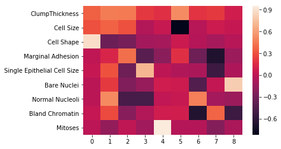

```python
sns.heatmap(pd.DataFrame(pc.components_,list(X.columns)))
```

# Content Based Recommendation System - Optional ( Q11 - Q18 will not be graded)

# Q11 Read the Dataset `movies_metadata.csv`

# Q12 Create a new column with name 'description' combining `'overview' and 'tagline'` columns in the given dataset

# Q13 Lets drop the null values in `description` column

# Q14 Keep the first occurance and drop duplicates of each title in column `title`

# Q15 As we might have dropped a few rows with duplicate `title` in above step, just reset the index [make sure you are not adding any new column to the dataframe while doing reset index]

# Q16 Create cosine similarity matrix

# Q17 Write a function with name `recommend` which takes `title` as argument and returns a list of 10 recommended title names in the output based on the above cosine similarities

Hint:

titles = df['title']  
indices = pd.Series(df.index, index=df['title'])

def recommend(title):  
idx = indices[title]  
sim_scores = list(enumerate(cosine_similarities[idx]))  
sim_scores = sorted(sim_scores, key=lambda x: x[1], reverse=True)  
sim_scores = sim_scores[1:31]  
movie_indices = [i[0] for i in sim_scores]  
return titles.iloc[movie_indices]

# Q18 Give the recommendations from above functions for movies `The Godfather` and `The Dark Knight Rises`

# Popularity Based Recommendation System

### About Dataset

Anonymous Ratings on jokes.

1. Ratings are real values ranging from -10.00 to +10.00 (the value "99" corresponds to "null" = "not rated").
2. One row per user
3. The first column gives the number of jokes rated by that user. The next 100 columns give the ratings for jokes 01 - 100.

# Q19 Read the dataset(jokes.csv)

Take care about the header in read_csv() as there are no column names given in the dataset.

```python
jk=pd.read_csv("jokes.csv")
```

```python
jk.head()
```

|  | NumJokes | Joke1 | Joke2 | Joke3 | Joke4 | Joke5 | Joke6 | Joke7 | Joke8 | Joke9 | ... | Joke91 | Joke92 | Joke93 | Joke94 | Joke95 | Joke96 | Joke97 | Joke98 | Joke99 | Joke100 |
| --- | --- | --- | --- | --- | --- | --- | --- | --- | --- | --- | --- | --- | --- | --- | --- | --- | --- | --- | --- | --- | --- |
| 0 | 74 | -7.82 | 8.79 | -9.66 | -8.16 | -7.52 | -8.50 | -9.85 | 4.17 | -8.98 | ... | 2.82 | 99.00 | 99.00 | 99.00 | 99.00 | 99.00 | -5.63 | 99.00 | 99.00 | 99.00 |
| 1 | 100 | 4.08 | -0.29 | 6.36 | 4.37 | -2.38 | -9.66 | -0.73 | -5.34 | 8.88 | ... | 2.82 | -4.95 | -0.29 | 7.86 | -0.19 | -2.14 | 3.06 | 0.34 | -4.32 | 1.07 |
| 2 | 49 | 99.00 | 99.00 | 99.00 | 99.00 | 9.03 | 9.27 | 9.03 | 9.27 | 99.00 | ... | 99.00 | 99.00 | 99.00 | 9.08 | 99.00 | 99.00 | 99.00 | 99.00 | 99.00 | 99.00 |
| 3 | 48 | 99.00 | 8.35 | 99.00 | 99.00 | 1.80 | 8.16 | -2.82 | 6.21 | 99.00 | ... | 99.00 | 99.00 | 99.00 | 0.53 | 99.00 | 99.00 | 99.00 | 99.00 | 99.00 | 99.00 |
| 4 | 91 | 8.50 | 4.61 | -4.17 | -5.39 | 1.36 | 1.60 | 7.04 | 4.61 | -0.44 | ... | 5.19 | 5.58 | 4.27 | 5.19 | 5.73 | 1.55 | 3.11 | 6.55 | 1.80 | 1.60 |

5 rows × 101 columns

```python
jk.shape
```

```
(24983, 101)
```

# Q20 Consider `ratings` named dataframe with only first 200 rows and all columns from 1(first column is 0) of dataset

```python
ratings=jk.iloc[0:200,1:101]
```

```python
ratings.shape
```

```
(200, 100)
```

```python
ratings.head()
```

|  | Joke1 | Joke2 | Joke3 | Joke4 | Joke5 | Joke6 | Joke7 | Joke8 | Joke9 | Joke10 | ... | Joke91 | Joke92 | Joke93 | Joke94 | Joke95 | Joke96 | Joke97 | Joke98 | Joke99 | Joke100 |
| --- | --- | --- | --- | --- | --- | --- | --- | --- | --- | --- | --- | --- | --- | --- | --- | --- | --- | --- | --- | --- | --- |
| 0 | -7.82 | 8.79 | -9.66 | -8.16 | -7.52 | -8.50 | -9.85 | 4.17 | -8.98 | -4.76 | ... | 2.82 | 99.00 | 99.00 | 99.00 | 99.00 | 99.00 | -5.63 | 99.00 | 99.00 | 99.00 |
| 1 | 4.08 | -0.29 | 6.36 | 4.37 | -2.38 | -9.66 | -0.73 | -5.34 | 8.88 | 9.22 | ... | 2.82 | -4.95 | -0.29 | 7.86 | -0.19 | -2.14 | 3.06 | 0.34 | -4.32 | 1.07 |
| 2 | 99.00 | 99.00 | 99.00 | 99.00 | 9.03 | 9.27 | 9.03 | 9.27 | 99.00 | 99.00 | ... | 99.00 | 99.00 | 99.00 | 9.08 | 99.00 | 99.00 | 99.00 | 99.00 | 99.00 | 99.00 |
| 3 | 99.00 | 8.35 | 99.00 | 99.00 | 1.80 | 8.16 | -2.82 | 6.21 | 99.00 | 1.84 | ... | 99.00 | 99.00 | 99.00 | 0.53 | 99.00 | 99.00 | 99.00 | 99.00 | 99.00 | 99.00 |
| 4 | 8.50 | 4.61 | -4.17 | -5.39 | 1.36 | 1.60 | 7.04 | 4.61 | -0.44 | 5.73 | ... | 5.19 | 5.58 | 4.27 | 5.19 | 5.73 | 1.55 | 3.11 | 6.55 | 1.80 | 1.60 |

5 rows × 100 columns

# Q21 Change the column indices from 0 to 99

```python
ratings.columns=range(0,100)
```

```python
ratings.sample(5)
```

|  | 0 | 1 | 2 | 3 | 4 | 5 | 6 | 7 | 8 | 9 | ... | 90 | 91 | 92 | 93 | 94 | 95 | 96 | 97 | 98 | 99 |
| --- | --- | --- | --- | --- | --- | --- | --- | --- | --- | --- | --- | --- | --- | --- | --- | --- | --- | --- | --- | --- | --- |
| 183 | 8.3 | 8.20 | 4.95 | 99.0 | 0.78 | 99.00 | 5.78 | -2.77 | 99.00 | 99.00 | ... | 99.0 | 99.0 | 99.0 | 99.0 | 99.0 | 99.0 | 99.00 | 99.0 | 99.0 | 99.0 |
| 143 | 99.0 | -1.12 | 99.00 | 99.0 | -1.17 | 1.17 | -0.87 | 2.28 | 99.00 | -0.34 | ... | 99.0 | 99.0 | 99.0 | 99.0 | 99.0 | 99.0 | 4.03 | 99.0 | 99.0 | 99.0 |
| 59 | 99.0 | -6.02 | 99.00 | 99.0 | 2.62 | 7.82 | 6.70 | -0.78 | -7.04 | -0.58 | ... | 99.0 | 99.0 | 99.0 | 99.0 | 99.0 | 99.0 | 99.00 | 99.0 | 99.0 | 99.0 |
| 116 | 99.0 | 99.00 | 99.00 | 99.0 | -5.49 | 99.00 | 5.15 | -1.89 | 99.00 | 99.00 | ... | 99.0 | 99.0 | 99.0 | 99.0 | 99.0 | 99.0 | 99.00 | 99.0 | 99.0 | 99.0 |
| 188 | 99.0 | 99.00 | 99.00 | 99.0 | 8.16 | 0.15 | 4.03 | 7.67 | 99.00 | 99.00 | ... | 99.0 | 99.0 | 99.0 | 99.0 | 99.0 | 99.0 | 99.00 | 99.0 | 99.0 | 99.0 |

5 rows × 100 columns

# Q22 In the dataset, the null ratings are given as 99.00, so replace all 99.00s with 0

Hint: You can use `ratings.replace(<the given value>, <new value you wanted to change with>)`

```python
ratings=ratings.replace(99.00,0)
```

```python
ratings.sample(5)
```

[output not shown]

```python
ratings.dtypes
```

[output not shown]

```python
ratings.head()
```

[output not shown]

5 rows × 100 columns

# Q23 Normalize the ratings using StandardScaler and save them in `ratings_diff` variable

```python
sc=StandardScaler()
ratings_diff=sc.fit_transform(ratings)
```

```python
ratings_diff
```

```
array([[ 0.17851402, -1.85701632,  1.67164929, ..., -0.02685824,
        -0.04144395, -0.16095388],
       [ 1.37166689,  0.78949409, -0.1802773 , ...,  0.07059963,
        -1.36765027,  0.16746078],
       [-0.96874834, -0.11788091, -0.12112987, ..., -0.02685824,
        -0.04144395, -0.16095388],
       ...,
       [ 1.37166689,  0.46479617, -0.89412566, ..., -0.23610604,
         0.18266036, -0.02590486],
       [-1.24409131, -0.11788091, -0.12112987, ..., -0.02685824,
        -0.04144395, -0.16095388],
       [ 0.04084254,  1.12308784, -1.60593445, ..., -0.02685824,
        -0.04144395, -0.16095388]])
```

### Popularity based recommendation system

# Q24 Find the mean for each column in `ratings_diff` i.e, for each joke

Consider all the mean ratings and find the jokes with highest mean value and display the top 10 joke IDs.

```python
mean_df=pd.DataFrame(ratings_diff.mean(axis=0))
```

```python
mean_df[0].sort_values(axis=0, ascending=False).head(10)
```

[output not shown]